# Image Analysis in Python: Working With DICOMs

⇦ Back

DICOM (Digital Imaging and Communications in Medicine) is a standard format for medical images that is widely used for storing and transferring medical image data.

# 1 Python Packages

The code on this page uses the Matplotlib and Pydicom packages, especially the latter which is a specialist package for working with DICOM images in Python. See its [documentation](https://pydicom.github.io/pydicom/stable/index.html) and its [homepage](https://pydicom.github.io/) for more. Install the packages by running the following in the terminal:

```bash
# "python3.12" should correspond to the version of Python you are using
python3.12 -m pip install matplotlib
python3.12 -m pip install pydicom
```

Once finished, import these packages along with the `datetime` module into your Python script as follows:

```python
# Matplotlib is for creating static, animated and interactive visualizations
from matplotlib import pyplot as plt
# pydicom is a pure Python package for working with DICOM files
import pydicom
# The datetime module supplies classes for manipulating dates and times
from datetime import datetime
```

If you’re on an Ubuntu machine or similar it’s possible that you will need to change some environment variables to be compatible with the Wayland system:

```python
# os provides a portable way of using operating system dependent functionality
import os

# Set the QT_QPA_PLATFORM environment variable to wayland
os.environ['QT_QPA_PLATFORM'] = 'wayland'
# Set the Matplotlib backend to one that is compatible with Wayland
plt.switch_backend('Agg')
```

# 2 Load a DICOM Image

This can be done with the `dcmread()` function from Pydicom:

```python
# Path to the DICOM file
path = 'I0000001.dcm'
# Load the DICOM file
ds = pydicom.dcmread(path)

print(type(ds))
```

```
## <class 'pydicom.dataset.FileDataset'>
```

# 3 Explore the Metadata

The `FileDataset` object will have a number of attributes that can be viewed (the below code is based on the [Read a Dataset and plot Pixel Data](https://pydicom.github.io/pydicom/stable/auto_examples/input_output/plot_read_dicom.html) tutorial that is provided in the documentation):

```python
print(f'SOP Class........: {ds.SOPClassUID} ({ds.SOPClassUID.name})')
patient_name = ds.PatientName
display_name = patient_name.family_name + ', ' + patient_name.given_name
print(f"Patient's Name...: {display_name}")
print(f'Patient ID.......: {ds.PatientID}')
print(f'Modality.........: {ds.Modality}')
dt = datetime.strptime(ds.StudyDate, '%Y%m%d')
print(f'Study Date.......: {dt.date()}')
print(f'Image size.......: {ds.Rows} x {ds.Columns}')
print(f'Pixel Spacing....: {ds.PixelSpacing}')
```

```
## SOP Class........: 1.2.840.10008.5.1.4.1.1.1.1 (Digital X-Ray Image Storage - For Presentation)
## Patient's Name...: NICHOLLS, ROWAN
## Patient ID.......: RTH10437278
## Modality.........: DX
## Study Date.......: 2019-08-02
## Image size.......: 1435 x 2948
## Pixel Spacing....: [0.0800, 0.0800]
```

Use `.get()` if you are not sure if the attribute exists or not and you want to get a default value if it is missing:

```python
print(f'Slice location...: {ds.get('SliceLocation', '(missing)')}')
```

```
## Slice location...: (missing)
```

You can see a list of all the attributes that the object has by running `dir()` (you can also view all of them by using the `to_json` attribute - `print(ds.to_json)`):

```python
print(dir(ds))
```

```
## ['AccessionNumber', 'AcquisitionContextSequence', 'AcquisitionDate', 'AcquisitionTime', 'AnatomicRegionSequence', 'BitsAllocated', 'BitsStored', 'BodyPartExamined', 'BurnedInAnnotation', 'Columns', 'ContentDate', 'ContentTime', 'DetectorID', 'DetectorType', 'DeviceSerialNumber', 'ExposureTime', '…
```

# 4 View the Image

Use Matplotlib to create a figure containing the image:

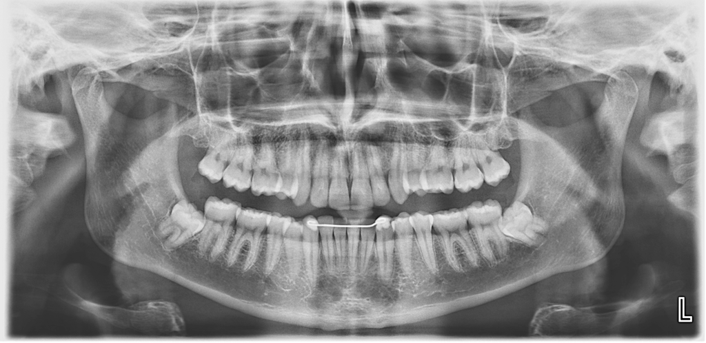

```python
# Create the image without axes or whitespace
figsize = (ds.pixel_array.shape[1] / 400, ds.pixel_array.shape[0] / 400)
plt.figure(figsize=figsize)
plt.imshow(ds.pixel_array, cmap='gray')
plt.axis('off')
plt.subplots_adjust(left=0, right=1, top=1, bottom=0)
plt.show()
```

This particular image is of my mouth prior to some dental work a few years back.

⇦ Back